# Data Challenge #1: Dairy Cow Visualizations

For this data challenge you will use the tidytuesday data on dairy cows to make five original paper quality figures with captions using the R libraries ggplot2 and dplyr. **Each figure should be well thought out and tell a cohesive story from the data.** The github repository containing the data can be found here:

https://github.com/rfordatascience/tidytuesday/tree/master/data/2019/2019-01-29

I have also posted the data on Canvas for your convenience.

A few requirements for the figures:

- Use at least five distinct plot types (i.e. histogram, scatterplot, barplot, stacked barplot, …)
- At least two figures should use a change of color from the default ggplot2 colors
- At least one figure should use a ‘join’ statement to join two of the dataframes together (or an external dataframe that you bring into the analysis)
- All plots should have a title
- Variable names are not acceptable for axis labels and legend labels
- Figure captions should be three to five sentences and describe the figure and trends in the data.

You will submit this assignment as an html file on Canvas. The code from your assignment should be visible in the html that you submit. Submit your .Rmd file to a GitHub repository and include a link to the repository at the top of the html that you submit on Canvas. Make the repository private and invite the instructor and both of the TAs to your repository.

The rubric for grading is shown below. The assignment is worth ** 100 pts**.

- **Code Style (10 pts)** Is code organized well and commented?
- **Submission (10 pts)** Was the data challenge submitted as an html document on Canvas? Did the html document contain code and written explanations of results? Does the html document look aesthetically pleasing? Did the homework contain a link for a GitHub repository? Did the repository contain the code for the assignment?
- **Overall Instructions (10 pts)** Were the above overall requirements satisfied for the plots (five types of plots, using a join statement etc.)?
- **Figure (10 pts each = 50 pts total)** Does each figure tell a compelling and understandable story from the data? Does each figure have a title? Were variable names not used for axis and legend?
- **Captions (4 pts each = 20 pts total)** Quality of figure captions. Are the captions well written? Do they describe the plot and some of the trend in the data?

Example code and an example figure are shown below (do not use this figure as part of your assignment – that would be plagiarism!). Note the detail of the code comments. Also note how the caption explains what is going on in the figure while also interpreting some of the trend in the data. This will be expected from your code and caption.

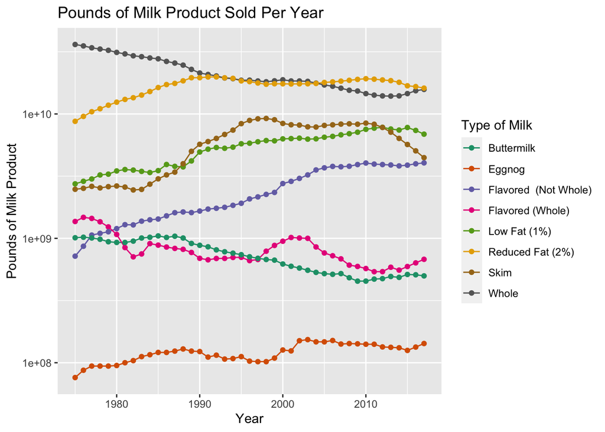

```r
## load in the required libraries
library(readr)
library(dplyr)
library(ggplot2)

## read in the data
state_milk_production <- read_csv("state_milk_production.csv")
clean_cheese <- read_csv("clean_cheese.csv")
fluid_milk_sales <- read_csv("fluid_milk_sales.csv")
milk_products_facts <- read_csv("milk_products_facts.csv")
milkcow_facts <- read_csv("milkcow_facts.csv")

## filter out milk type of Total Production from the data
fluid_milk_sales_plot <- fluid_milk_sales %>%
  filter(milk_type != 'Total Production')

## plot of milk product sales over time
ggplot(fluid_milk_sales_plot,  ## initalizes ggplot object of pounds verus year grouped and colored by milk type
       aes(x = year,
           y = pounds,
           group = milk_type,
           color = milk_type)) +
  geom_line() + ## make a line plot
  geom_point() + ## add points along line
  scale_y_continuous(trans='log10') +  ## log base 10 transform the data
  ggtitle('Pounds of Milk Product Sold Per Year') +  ## add title
  ylab('Pounds of Milk Product') + ## change y-axis label
  xlab('Year') + ## change x-axis label
  labs(color = "Type of Milk") +  ## change title of legend
  scale_color_brewer(palette="Dark2") ##change color scheme of plot
```

**Figure 1:** This plot shows the amount (in pounds) of milk products sold over time between 1975 and 2017. The sales of skim, low fat (1%), and reduced fat (2%) milks have increased over time, while the sales of whole milk have decreased over time. Whole milk had the largest amount of sales until around the 1990s, where reduced fat milk had equal sales and then surpassed that of whole milk in 2005.